https://www.kaggle.com/code/ash316/eda-to-prediction-dietanic/notebook

# EDA 필사

[figure not shown]

벌써 절반까지 달려오신 여러분! 너무 고생 많으셨습니다. 8주차에서 절반에 해당하는 4주차까지 모델링이 아닌 데이터에 대해 이렇게 시간을 쏟은 이유는 프로젝트를 수행할 때, 생각보다 데이터를 마음대로 다룰 수 있는 기본기가 중요하기 때문입니다.

그렇지 않으면, 남들이 깨끗하게 만들어 놓은 데이터셋만을 가지고 모델링을 해야하는데, 그런 사람과 어떤 데이터든 원하는 형태로 바꿔가며 모델에 맞출 수 있는 사람은 하늘과 땅차이라고 생각합니다. 그만큼 데이터 전처리와 EDA는 프로젝트에 있어 매우 중요한 역할을 하기 때문에, 시간을 조금 들이더라도 최대한 익숙해지는 과정을 여러분과 함께했습니다. 이번 주차엔 살짝 쉬어가는 느낌으로 `EDA 필사`를 진행합니다.

> **창작의 시작은 모방이다**

라는 말이 있죠? 누구나 처음부터 잘할 수는 없습니다. 다만, 잘하는 사람은 어떻게 하는지 보고 배울 수는 있죠. 이번 시간엔 우리가 지지난 시간에 다뤄봤던 `Titanic` 데이터를 가지고 고수는 어떻게 EDA를 했는지 하나하나 따라해보겠습니다.

#### 필사? 그냥 코드 따라치는 거 아닌가요? 이게 의미가 있나요?

그냥 복붙을 하면 말씀하신 대로 정말 의미가 없습니다. 그러나 필사를 하게 되면 우리는 코드의 "흐름"을 함께 따라가면서 몰랐던 부분은 새로 알게 되고, 알았던 부분에 대한 확신을 가지게 됩니다. 필사는 단순한 노동이 아닌, 코드의 흐름을 따라가보고 익히는 과정으로 이해하시면 좋을 거 같습니다 ㅎㅎ

**알림**

- 본 컨텐츠는 강의 형식이 아닌, 스스로 공부하시는 분들을 위한 일종의 문제집 입니다.
- 데이터라는 큰 바다에서 여러분이 쓸 데 없는 시간 낭비 없이 바로바로 핵심을 배우실 수 있도록 커리큘럼을 짜봤습니다.
- 이 컨텐츠의 문제들만 해결한다고 실력이 오르지 않습니다. 본 컨텐츠의 목적은 문제를 해결하는 과정에서 발생하는 고민과 질문을 통한 실력 향상입니다.
- 문제에서 절대 떠먹여주지 않습니다. 물고기를 잡아주는 것이 아닌, 물고기를 잡는 방법을 여러분이 이 컨텐츠를 통해 알아가셨으면 합니다.

### ❗주의❗

> 이번 필사 컨텐츠는 복붙을 최대한 지양합니다. 물론 복붙을 하시는 것을 제가 막을 수는 없지만, 복붙을 하게 되면 이 컨텐츠는 그 순간부터 공부가 아닌 노동이 되어버립니다. 컨텐츠로부터 최대한 많은 공부를 하셨으면 하는 바람으로, 복붙은 최대한 삼가주시길 부탁드립니다.

# EDA 소개

https://www.kaggle.com/code/ash316/eda-to-prediction-dietanic/notebook

이번 컨텐츠에서 필사해볼 EDA는 `EDA To Prediction(DieTanic)` 입니다. `Ashwini Swain`이라는 사람이 5년 전에 작성한 EDA인데, 사실 아직까지도 필사하면서 연습하기 좋은 EDA로 남아있습니다. 그만큼 모범적이었다는 거죠 ㅎㅎ

우리도 할 수 있습니다. 하나하나 따라가보면서 어떻게 했는지 알아보겠습니다.

**🚩 필사를 하는 도중, `새로 알게된 것들`이나 `의문점`들은 코드 옆에 주석으로 표시해두시는 걸 추천드립니다! 나중에 뭘 배웠고 어떤 의문점이 들었는지를 정리할 때 많은 도움이 될 거예요!**  
*예시*

```
import numpy as np
import pandas as pd
import matplotlib.pyplot as plt
import seaborn as sns
plt.style.use('fivethirtyeight')  # plt.style을 지정해주면 신경 쓰지 않아도 알아서 이쁜 스타일을 고를 수 있다!!!!
import warnings
warnings.filterwarnings('ignore') # 쓸 데 없이 나오는 경고문들을 무시할 수 있다!
%matplotlib inline # matplotlib의 결과물을 바로 확인할 수 있게 해주는 코드구나!
```

## 관련 라이브러리 import

```python
import numpy as np
import pandas as pd
import matplotlib.pyplot as plt
import seaborn as sns
plt.style.use('fivethirtyeight')
import warnings
warnings.filterwarnings('ignore')
%matplotlib inline
```

### 데이터 불러오기 및 확인

```python
data = pd.read_csv('./titanic.csv')
print(data.isnull().sum())
data.head()
```

```
PassengerId      0
Survived         0
Pclass           0
Name             0
Sex              0
Age            177
SibSp            0
Parch            0
Ticket           0
Fare             0
Cabin          687
Embarked         2
dtype: int64
```

|  | PassengerId | Survived | Pclass | Name | Sex | Age | SibSp | Parch | Ticket | Fare | Cabin | Embarked |
| --- | --- | --- | --- | --- | --- | --- | --- | --- | --- | --- | --- | --- |
| 0 | 1 | 0 | 3 | Braund, Mr. Owen Harris | male | 22.0 | 1 | 0 | A/5 21171 | 7.2500 | NaN | S |
| 1 | 2 | 1 | 1 | Cumings, Mrs. John Bradley (Florence Briggs Th... | female | 38.0 | 1 | 0 | PC 17599 | 71.2833 | C85 | C |
| 2 | 3 | 1 | 3 | Heikkinen, Miss. Laina | female | 26.0 | 0 | 0 | STON/O2. 3101282 | 7.9250 | NaN | S |
| 3 | 4 | 1 | 1 | Futrelle, Mrs. Jacques Heath (Lily May Peel) | female | 35.0 | 1 | 0 | 113803 | 53.1000 | C123 | S |
| 4 | 5 | 0 | 3 | Allen, Mr. William Henry | male | 35.0 | 0 | 0 | 373450 | 8.0500 | NaN | S |

### 생존자 시각화 (Class 분포 확인)

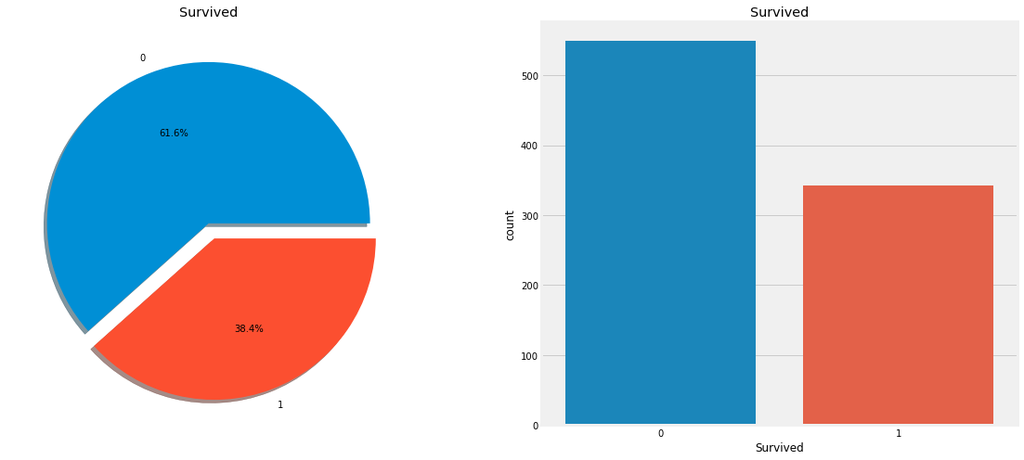

```python
f, ax = plt.subplots(1, 2, figsize=(18, 8))
data['Survived'].value_counts().plot.pie(explode=[0,0.1],autopct='%1.1f%%',ax=ax[0],shadow=True)
ax[0].set_title('Survived')
ax[0].set_ylabel('')
sns.countplot('Survived',data=data,ax=ax[1])
ax[1].set_title('Survived')
plt.show()
```

코드 필사를 통해 배운 지식, 의문점, 파악할 수 있는 정보 등을 자유롭게 적어주세요.

### Feature와 Class 관계 파악하기

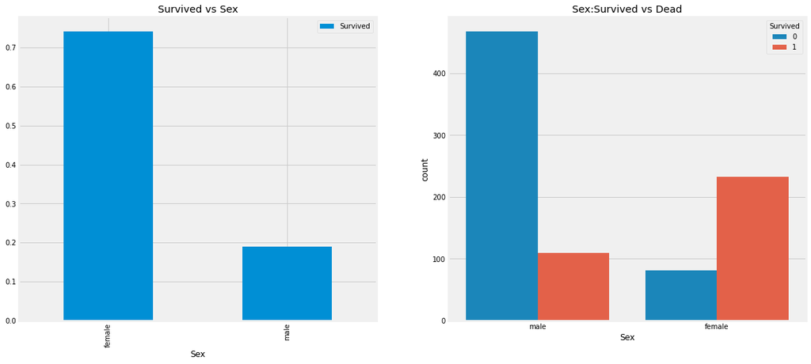

```python
## 성별과 생존과의 관계

f,ax=plt.subplots(1,2,figsize=(18,8))
data[['Sex','Survived']].groupby(['Sex']).mean().plot.bar(ax=ax[0])
ax[0].set_title('Survived vs Sex')
sns.countplot('Sex',hue='Survived',data=data,ax=ax[1])
ax[1].set_title('Sex:Survived vs Dead')
plt.show()
```

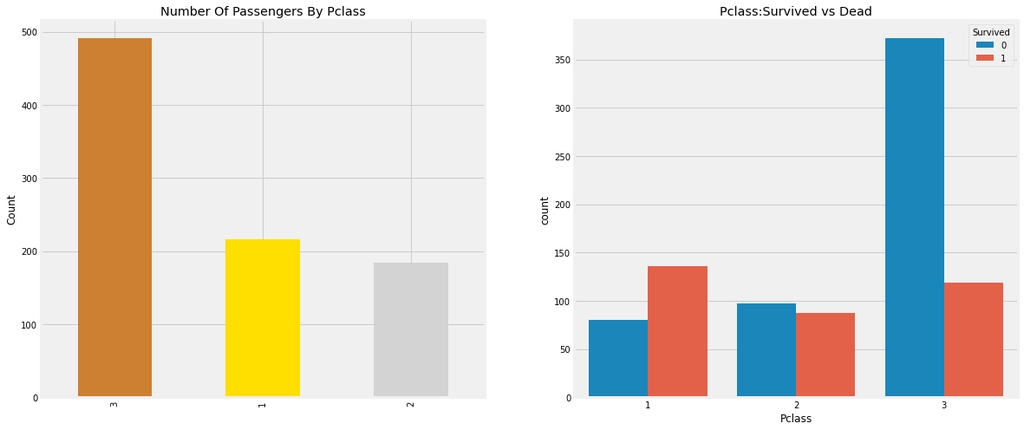

```python
## 선실 등급과 샌존과의 관계

f,ax=plt.subplots(1,2,figsize=(18,8))
data['Pclass'].value_counts().plot.bar(color=['#CD7F32','#FFDF00','#D3D3D3'],ax=ax[0])
ax[0].set_title('Number Of Passengers By Pclass')
ax[0].set_ylabel('Count')
sns.countplot('Pclass',hue='Survived',data=data,ax=ax[1])
ax[1].set_title('Pclass:Survived vs Dead')
plt.show()
```

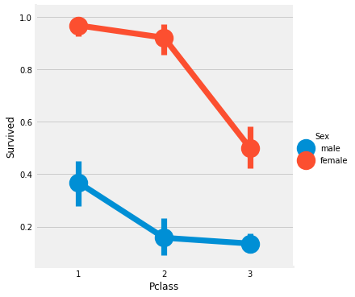

```python
sns.factorplot('Pclass','Survived',hue='Sex',data=data)
plt.show()
```

위의 2개의 그림과 `FactorPlot`을 고려했을 때, 어떤 사실을 알아낼 수 있나요?

### Age 공략하기

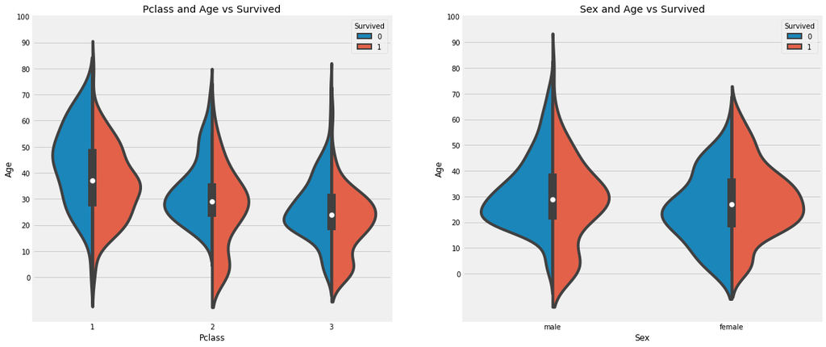

```
# of Null Values of Age Column:  177
```

```python
f,ax=plt.subplots(1,2,figsize=(18,8))
sns.violinplot("Pclass","Age", hue="Survived", data=data,split=True,ax=ax[0])
ax[0].set_title('Pclass and Age vs Survived')
ax[0].set_yticks(range(0,110,10))
sns.violinplot("Sex","Age", hue="Survived", data=data,split=True,ax=ax[1])
ax[1].set_title('Sex and Age vs Survived')
ax[1].set_yticks(range(0,110,10))
plt.show()

print("# of Null Values of Age Column: ", data['Age'].isnull().sum())
```

📌한번 같이 생각해봐요!📌  
아래는 Age Column에 비어있는 177개의 값을 채우기 위한 아이디어 입니다.

이 분은 Age에 비어 있는 값을 채워주기 위해, 평균값을 이용하여 채워주려고 했지만, 위의 시각화 자료를 보아하니, 연령대의 분포가 너무 다양하여 평균값 하나로만 채우기 애매했죠. 단순히 평균값으로 채워버리면, 4세의 정보에 평균값인 29살을 넣어버리는 경우가 발생할 수 있었습니다.

이를 해결하기 위한 아이디어로 저자는 `Name`에서 그 힌트를 활용하기로 합니다.  
`Name`을 잘 보면, *mr*, *mrs* 와 같이 이름에 대한 정보로 데이터를 구분할 수 있다는 사실을 알아낼 수 있습니다.

즉!!!! Age의 null 값을 단순 평균치가 아닌, 이름에서 힌트를 얻어 이들의 평균값으로 대체하면, 조금 더 세밀한 결측치 제거가 가능하다는 것이죠!

한번 어떻게 했는지 따라가봅시다 :)

```python
## 먼저, 이름에서 특정한 부분을 추출해봅시다.
data['Initial']=0
for i in data:
    data['Initial']=data.Name.str.extract('([A-Za-z]+)\.') # 이 정규식은 무엇을 의미할까요? 헷갈리면... 정규식 고수 유우비트님께 물어봅시다..! ㅎㅎ
data
```

|  | PassengerId | Survived | Pclass | Name | Sex | Age | SibSp | Parch | Ticket | Fare | Cabin | Embarked | Initial |
| --- | --- | --- | --- | --- | --- | --- | --- | --- | --- | --- | --- | --- | --- |
| 0 | 1 | 0 | 3 | Braund, Mr. Owen Harris | male | 22.0 | 1 | 0 | A/5 21171 | 7.2500 | NaN | S | Mr |
| 1 | 2 | 1 | 1 | Cumings, Mrs. John Bradley (Florence Briggs Th... | female | 38.0 | 1 | 0 | PC 17599 | 71.2833 | C85 | C | Mrs |
| 2 | 3 | 1 | 3 | Heikkinen, Miss. Laina | female | 26.0 | 0 | 0 | STON/O2. 3101282 | 7.9250 | NaN | S | Miss |
| 3 | 4 | 1 | 1 | Futrelle, Mrs. Jacques Heath (Lily May Peel) | female | 35.0 | 1 | 0 | 113803 | 53.1000 | C123 | S | Mrs |
| 4 | 5 | 0 | 3 | Allen, Mr. William Henry | male | 35.0 | 0 | 0 | 373450 | 8.0500 | NaN | S | Mr |
| ... | ... | ... | ... | ... | ... | ... | ... | ... | ... | ... | ... | ... | ... |
| 886 | 887 | 0 | 2 | Montvila, Rev. Juozas | male | 27.0 | 0 | 0 | 211536 | 13.0000 | NaN | S | Rev |
| 887 | 888 | 1 | 1 | Graham, Miss. Margaret Edith | female | 19.0 | 0 | 0 | 112053 | 30.0000 | B42 | S | Miss |
| 888 | 889 | 0 | 3 | Johnston, Miss. Catherine Helen "Carrie" | female | NaN | 1 | 2 | W./C. 6607 | 23.4500 | NaN | S | Miss |
| 889 | 890 | 1 | 1 | Behr, Mr. Karl Howell | male | 26.0 | 0 | 0 | 111369 | 30.0000 | C148 | C | Mr |
| 890 | 891 | 0 | 3 | Dooley, Mr. Patrick | male | 32.0 | 0 | 0 | 370376 | 7.7500 | NaN | Q | Mr |

891 rows × 13 columns

```python
## 뽑아낸 이니셜이 성별로 어떤 분포를 가지고 있는지 표로 살펴봅시다
pd.crosstab(data.Initial,data.Sex).T
```

| Initial Sex | Capt | Col | Countess | Don | Dr | Jonkheer | Lady | Major | Master | Miss | Mlle | Mme | Mr | Mrs | Ms | Rev | Sir |
| --- | --- | --- | --- | --- | --- | --- | --- | --- | --- | --- | --- | --- | --- | --- | --- | --- | --- |
| female | 0 | 0 | 1 | 0 | 1 | 0 | 1 | 0 | 0 | 182 | 2 | 1 | 0 | 125 | 1 | 0 | 0 |
| male | 1 | 2 | 0 | 1 | 6 | 1 | 0 | 2 | 40 | 0 | 0 | 0 | 517 | 0 | 0 | 6 | 1 |

```python
## 일부 발생한 오타를 replace 함수를 통해 정리해줍니다.
data['Initial'].replace(
    ['Mlle','Mme','Ms','Dr','Major','Lady','Countess','Jonkheer','Col','Rev','Capt','Sir','Don'],
    ['Miss','Miss','Miss','Mr','Mr','Mrs','Mrs','Other','Other','Other','Mr','Mr','Mr'],
    inplace=True)
print(data.groupby('Initial')['Age'].mean()) # 평균값 확인!
```

```
Initial
Master     4.574167
Miss      21.860000
Mr        32.739609
Mrs       35.981818
Other     45.888889
Name: Age, dtype: float64
```

```python
# 이제 각 이니셜 별로 평균 나이를 알아냈으니, 각 평균값에 맞게 채워줍니다.
# pandas에서 배웠던 loc는 이런 식으로 활용됩니다 :)
data.loc[(data.Age.isnull())&(data.Initial=='Mr'),'Age']=33
data.loc[(data.Age.isnull())&(data.Initial=='Mrs'),'Age']=36
data.loc[(data.Age.isnull())&(data.Initial=='Master'),'Age']=5
data.loc[(data.Age.isnull())&(data.Initial=='Miss'),'Age']=22
data.loc[(data.Age.isnull())&(data.Initial=='Other'),'Age']=46

print("결측치 제거 후 남은 결측치: ",data.Age.isnull().sum())
```

```
결측치 제거 후 남은 결측치:  0
```

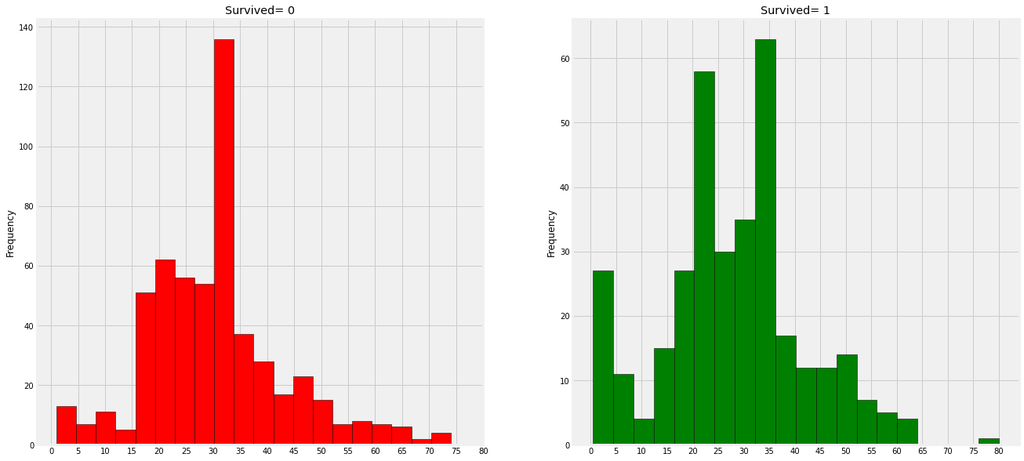

```python
## 최종 생존여부 별 연령대 확인
f,ax=plt.subplots(1,2,figsize=(20,10))
data[data['Survived']==0].Age.plot.hist(ax=ax[0],bins=20,edgecolor='black',color='red')
ax[0].set_title('Survived= 0')
x1=list(range(0,85,5))
ax[0].set_xticks(x1)
data[data['Survived']==1].Age.plot.hist(ax=ax[1],color='green',bins=20,edgecolor='black')
ax[1].set_title('Survived= 1')
x2=list(range(0,85,5))
ax[1].set_xticks(x2)
plt.show()
```

위의 과정에서 어떤 걸 알 수 있었나요? 추가적으로 아래의 질문에도 답을 달아보세요!

- 영아(5세 미만)들은 최우선적으로 구해진 것같나요?
- 생존자 중, 가장 나이가 많은 사람은 몇 세인가요?
- 가장 많이 죽음을 당한 연령대는 몇 세인가요?

### 탑승항구와 생존여부

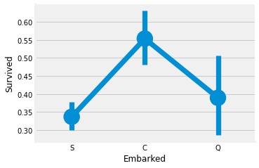

```python
sns.factorplot('Embarked','Survived',data=data)
fig=plt.gcf()
fig.set_size_inches(5,3)
plt.show()
```

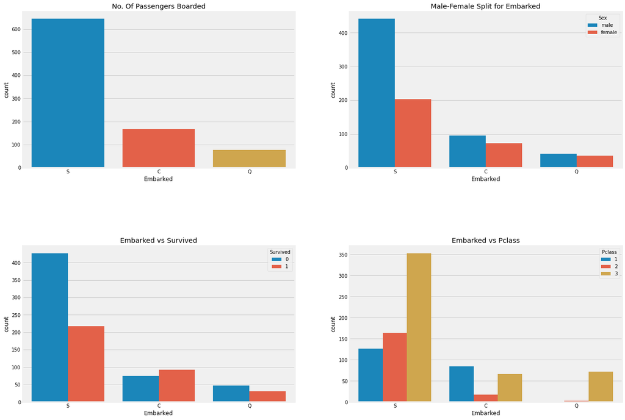

```python
f,ax=plt.subplots(2,2,figsize=(20,15))
sns.countplot('Embarked',data=data,ax=ax[0,0])
ax[0,0].set_title('No. Of Passengers Boarded')
sns.countplot('Embarked',hue='Sex',data=data,ax=ax[0,1])
ax[0,1].set_title('Male-Female Split for Embarked')
sns.countplot('Embarked',hue='Survived',data=data,ax=ax[1,0])
ax[1,0].set_title('Embarked vs Survived')
sns.countplot('Embarked',hue='Pclass',data=data,ax=ax[1,1])
ax[1,1].set_title('Embarked vs Pclass')
plt.subplots_adjust(wspace=0.2,hspace=0.5)
plt.show()
```

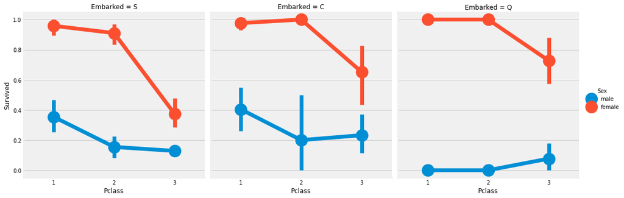

```python
sns.factorplot('Pclass','Survived',hue='Sex',col='Embarked',data=data)
plt.show()
```

탑승 선착장의 종류별로 다른 Feature들과 함께 비교해봤습니다. 어떤 점을 여기서 유추해볼 수 있나요? 다음의 질문에 대답해보면서 답을 적어보세요!

- 가장 많은 승객이 탑승한 선착장은 어디고, 대부분 몇 등급의 선실이었나요?
- 마지막 그림에서, S 선착장에서 알아낼 수 있는 사실은 무엇인가요?

## 4주차 종료

- 절반까지 달려오신 여러분! 모두 고생 많으셨습니다.
- 이번 EDA 필사를 진행하면서, 고수의 인사이트와 기술을 많이 배우신 분도 계실 거고, 단순 노동으로 느껴지신 분들도 계실 거 같습니다
- 2주에 걸쳐 EDA를 한 이유는, 데이터 수집부터 배포까지 이루어지는 모델의 Cycle에서 앞으로의 방향성과 남들과 차별화를 둘 수 있는 전략이 바로 대부분 EDA에서 나오기 때문입니다. (Dacon이나 Kaggle만 들어가보셔도 금방 공감하실 수 있을 거예요!)
- **다음주부터 본격적으로 ML 컨텐츠에 들어갑니다.**
- ML은 총 3주에 걸쳐 진행될 예정으로, 다음 컨텐츠는 시험기간이기도 하니, 머신러닝의 전반적인 플로우를 함께 따라가보면서 어떤 녀석인지 확인해보는 시간을 가져보겠습니다 ㅎㅎ

## 숙제

- 이번 컨텐츠 숙제는 간단합니다.
- `여러분이 EDA 필사를 진행하면서 새로 알게 된 내용이나 깨달은 내용을 블로그에 정리`해주세요!
- 추천 방법은 코드 하나하나를 따라가시면서 주석 다셨던 내용을 기반으로 *이 코드는 이런 원리로 작동하는 구나!* 혹은 *아 이 분은 이 데이터에서 이런 인사이트를 얻었구나!* 혹은 *이렇게 굳이 안 해도 요렇게 해도 될 거 같은데?* 와 같은 내용들을 작성하시는 것을 추천드립니다 ㅎㅎ

### 질문은 언제나 환영입니다!